# Statistical Rethinking

# Statistical Rethinking Notes and Exercises

```r
library(rethinking)
```

```r
rstan_options(auto_write = TRUE)
options(mc.cores = parallel::detectCores(logical = FALSE))

# helper functions
lmplot <- function(formula, model, fit.data, x.seq, plot.data,
                   prob=.97) {
  mu <- link(model, data=fit.data)
  mu.mean <- apply(mu, 2, mean)
  mu.ci <- apply(mu, 2, HPDI, prob=prob)

  h.sim <- sim(model, data=fit.data)
  h.ci <- apply(h.sim, 2, HPDI, prob=prob)

  plot(formula, data=plot.data, col='slateblue')
  lines(x.seq, mu.mean)
  # confidence interval
  lines(x.seq, mu.ci[1,], lty=2)
  lines(x.seq, mu.ci[2,], lty=2)
  # prediction interval
  shade(h.ci, x.seq)
}

get_posterior <- function(likelihood, prior) {
  posterior <- likelihood * prior
  posterior <- posterior / sum(posterior)
  return(posterior)
}
```

# Useful Functions

- `rethinking::postcheck` default posterior validation function. Essentially fits training data.
- `rethinking::glimmer` builds a `map`/`map2stan` style formula frmo `glm` model formula
- `rethinking::coerce_index` converts categories into numerical coding.
- `rethinking::pairs` pair plot for model parameters.
- `stats::quantile`
- `base::by`

**MAP** stands for **MAXIMUM A POSTERIOR**, fancy latin name for the mode of the posterior distribution.

# Chapter 3

- **PI**, Percentile Intervals, p56. `rethinking::PI()`. Assigns equal probability mass to each tail. It does a good job describing the shape of the distribution, **as long as it isn’t too asymmetrical**.
- **HPDI**, Highest Posterior Density Interval, p56, `rethinking::HPDI()`. It is the narrowest interval that contains the specified probablity mass. This is much better than `PI` for inference.
  - However, it is computationally more intensive
  - suffers from **simulation variance**, i.e. sensitive to the number of samples drawn from the posterior.
- We should not be using intervals to describe the posterior if the choice of which type of interval makes a difference. Bayesian estimates give the entire posterior distribution anyway.

## Grid Approximation

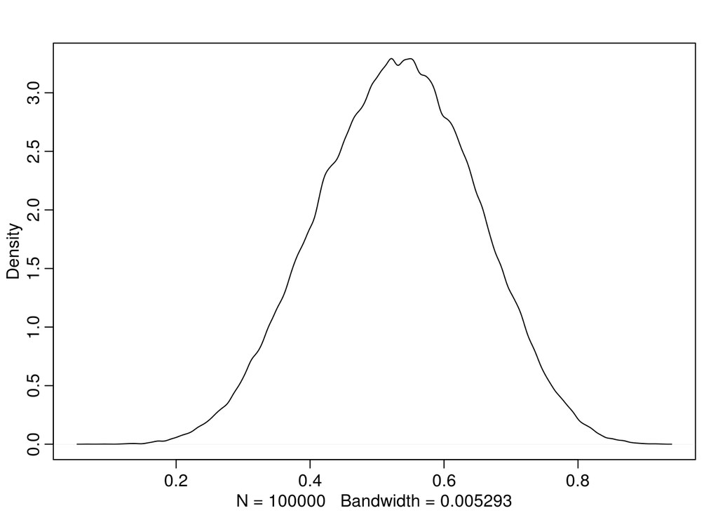

```r
# parameter grid
grid.size <- 1000

p_grid <- seq(from=0, to=1, length.out = grid.size)

# un-informative prior
prior <- rep(1, grid.size)

# binomial likelihood, 8 successes out of 15 trials, with probability given
# by p_grid
likelihood <- dbinom(8, size=15, prob = p_grid)

posterior <- likelihood * prior
posterior <- posterior / sum(posterior)

# sample from p_grid, each paramter with probabilty specified in posterior
samples <- sample(p_grid, prob = posterior, size=1e5, replace = TRUE)

dens(samples)
```

Generating dummy data.

```r
# sample from binomial distribution, 10 runs, each with 9 samples, with
# prob of success = 0.7
rbinom(10, size=9, prob = .6)
```

```
##  [1] 7 8 4 5 2 5 4 7 7 4
```

```r
# 1e5 simulations, 9 samples each time, use probablity from the previous samples
w <- rbinom(1e5, size = 9, prob = samples)
table(w) / 1e5
```

```
## w
##       0       1       2       3       4       5       6       7       8
## 0.00581 0.02763 0.07649 0.13918 0.19251 0.20802 0.17772 0.11152 0.04929
##       9
## 0.01183
```

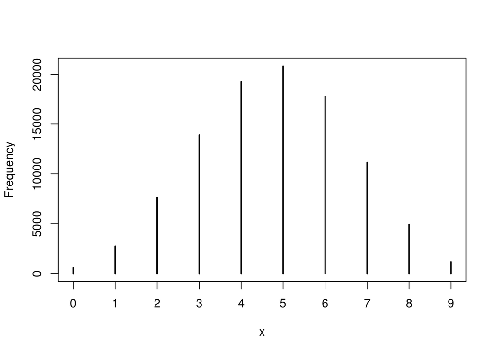

```r
simplehist(w)
```

# Chapter 4 Linear Models

How strong is a prior, p89 Overthinking it

The amount of data implied by a prior can be computed for Gaussian posterior, for $\mu \sim \mathcal{N}(178, 0.1)$:

$$\begin{aligned}
\sigma_{post} &= 1 / \sqrt{n} \\
\therefore n &= 1 / \sigma_{post}^2 \\
\ n &= 1/(0.1)^2 = 100
\end{aligned}$$

## Confidence Interval, p102-106

Once we have a fitted model, we draw samples from the parameter posterior distributions to calcluate the fitted values along a sequence of possible predictors. The PDF of such fitted values should mirror the PDF of parameter posterior distributions, i.e. more samples with values near the posterior MAP.

The **link function** essentially calculates fitted values, using a model defined by the samples draw above.

Each fit in this result is a distribution of possible values (based on sample of parameters, say 1e4 nobs).

The **mean** of this distribution is the **fitted** value.

Its **HPDI** is the confidence interval band.

## Prediction Interval, p107

Similar to above:

1. draw samples from the parameter posterior distributions.
2. generate a sequence of possible predictor values for fitting.
3. for each data point from 2), draw random samples from a distribution defined by mean of fitted value (based on MAP parameters) and model posterior variance.
4. `rethinking::PI` or `rethinking::HPDI` of the results from 3) gives the prediction interval for that data point.

This can be down with `rethinking::sim`.

# Chapter 5

Plots that help with examining multivariate models, p126:

1. Predictor residual plots, outcome vs residuals
2. Counterfactual plots, hold other variables constant, fit with a range of values for one predictor.
3. Posterior prediction plots, predicted versus observed.

Issues with linear regression

1. Multicollinearity, correlated features, causing large intervals for parameter estimates.
2. Post-treatment Bias
3. Overfitting

# Chapter 6

## Measuring Accuracy

Maximizing the joint probability of data is the correct way to identify the right model. E.g. Multiplying the probabilities of each correct prediction (i.e. computed by using the prob density function of the model of data).

Taking the average is **not** the right way to do it.

## Information Theory

The measurement of information should satisfy:

- should be continuous
- should increase as the number of possible evens increases
- should be additive

### Entropy

The probabilities $p_i$ of data is computed as as follows: first, have a probabilistic model of the underlying event, this is a probability distribution, using its probability density function, compute the probability $p_i$ of data using this probabilistic model.

$$H(p) = -\mathbb{E}(\log(p_i)) = -\sum_{i=1}^{n}p_i \log(p_i)$$

### Cross Entropy

Minimizing cross-entropy is essentially minimizing the distance between the model and the underlying true distribution (which is unknown).

$$H(p, q) = -\sum_{i=1}^{n}p_{i}\log(q_i)$$

### Kullback-Leibler Divergence

**Divergence** captures the additional uncertainty induced by using probabilties from one distribution to describe another distribution.

$$D_{KL} = \sum_i p_i(\log(p_i) - \log(q_i)) = \sum_i p_i \log\Big(\frac{p_i}{q_i}\Big)$$

### Deviance

From KL Divergence, in practice we do not know the true model, $p_i$. What we care about instead is between two models, $q$ and $r$, which one is closer to $p$. By subtracting two KL divergence terms together, most of the terms involving $p$ are cancelled out. Hence we define deviance:

$$D(q) = -2\sum_{i}\log(q_i) \approx D_{KL}-D_{KL}$$

`stats::logLik` computes the log-probabilities, know as **log-likelihood of the data**. Hence: `deviance = -2 * logLik(model)`.

Deviance has the same flaw as $R^2$, it always improves as the model gets more complex. Deviance in-sample is **not** a measure of out of sample predictive accuracy.

When fitting multiple models for comparison, it is important that all models are fitted with the same set of data. Otherwise, models fitted with less data will have lower information criteria values, because they are asked to predict less. p196

## Information Criteria

Deviance provides a measure for in-sample / training data model evaluation. We need a measure to evaluate models for for out-of-sample / test data. This is where AIC, DIC and WAIC come in.

The validity of these metrics depends upon the predictive task at hand.

My opinion: these are metrics designed to estimate OOS deviance, not sure in practice these work well. Maybe when you have lots of data, cross validation is just a more practical method to tune the models, and compare models based on test errors.

### AIC, page 189

AIC is reliable only when:

1. flat prior, or overwhelmed by likelihood (data)
2. The posterior distribution is approximately multivariate Gaussian
3. The sample size N is much larger than the number of parameters k

$$AIC = D_{train} + 2p$$
where $p$ is the number of free parameters to be estimated in the model.

### DIC, page 190

1. can handle informative priors
2. still rquires 2 and 3 above like AIC
3. In the case of flat priors, DIC reduces to AIC.

Because DIC also assumes multivariate Gaussian posterior distributon, if any parameter in the posterior is substantially skewed, **and** also has a substantial effect on the prediction, then DIC like AIC can go horribly wrong.

$$DIC = \bar{D} + (\bar{D} - \hat{D}) = \bar{D} + p_D$$
Where:

$D$ is the posterier distribution of deviance

$\bar{D}$ is the average of $D$

$\hat{D}$ is the deviance calculated at the posterier mean

$p_D$, known as the penalty term, is just the expected distance between the deviance in-sample and the deviance out-of-sample.

### WAIC, p191

- Does not require posterior distribution to be multivariate Gaussian.
- Often more accurate than DIC

WAIC requires splitting data into **independent** observations. In time series, where an observation may depend on the previous observation, this is **not** satisfied, in this case it is **not** clear what the calculated WAIC means.

- `rethinking::compare()` compares models using WAIC. p199
  - open points are WAIC
  - filled points are in-sample deviance, (4) below
  - dark line across WAIC points are the standard errors
  - triangles show the differences between the model below it and the top model
  - line across triangles are the standard deviation of the differences.
  - the weights are **Akaike weights** for each model. Analogous to posterior probabilities of models, conditional on expected future data.

Steps to calculate WAIC, p192 Overthinking box:

1. fit model
2. extract samples from model parameters
3. for each smaple of parameters, create a posterior distribution, calculate density for each outcome. I.e. this steps calculates $Pr(y_i)$
4. calculate **lppd** (log-pointwise-predictive-density),

$$lppd=\sum_{i=1}^{N}\log(Pr(y_i))$$

5. calculate the **effective number of paramters**,

$$p_{WAIC}=\sum_{i=1}^{N}Var(y_i)$$

6. finally we have WAIC:

$$WAIC = -2 (lppd - p_{WAIC})$$

### BIC

Also known as Schwarz criterion.

**Bayes Factor** is a ratio of average likelihoods (the denominator in Bayes theorem). There are technical issues related to using bayes factor as a measure of OOS model evaluation.

### Cross Validation, Ensemble Methods

- `rethinking::sim.train.test()` can be used to run leave one out cross validation. p184. See instruction in Overthinking box on page 185 on parameters to parallelise the simulations.
- `rethinking::ensemble()` can be used to calcluate model averaged results.

Example:

```
milk.ensemble <- ensemble(model1, model2, model3, data=d.predict)
```

Notes from solutions for 6M1:

- From most general to least general: WAIC, DIC, AIC.
- When the posterior predictive mean is a good representation of the posterior predictive distribution, DIC and WAIC will tend to agree.
- When priors are effectively flat or overwhelmed by the amount of data, the DIC and AIC will tend to agree.

**Positive $\sigma$ trick**: model $log(\sigma)$ instead, therefore $\sigma$ is $exp(x)$ which is always > 0. Example:

```
a.start <- mean(d$kcal.per.g)
sigma.start <- log(sd(d$kcal.per.g))  # input sigmal is in log scalue
m6.11 <- map(
  alist(
      kcal.per.g ~ dnorm( a , exp(log.sigma) )
  ) ,
  data=d , start=list(a=a.start,log.sigma=sigma.start) )
```

# Chapter 7

1. Incorporating uncertainty for the linear model of slope $\gamma$, this must be calculated separately, i.e. not obvious from the model results. p221
2. Symmetry of the lineary interaction
- **Triptych plots**, p233

# Chapter 8

## MCMC

- Samples directly from the joint posterior of a model without maximizing anything
- Without Gaussian posterior assumptions

## Gibbs Sampling

- Metropolis algorithm handles **symmetric** probabilities
- Metropolis-Hastings allows **asymmetric** probabilities.
- Gibbs Sampling is a variant of Metropolis-Hastings algo that use smarter proposals, therefore more efficient.
- Gibbs Sampling uses **conjugate pairs** of prior distributions and likelihoods.
- **Limitations**: 1) necesseity of using conjugate priors, b) tendency to get stuck in the regions of posterior when the posterior distribution has either highly correlated parameters or high dimensions.

## HMC

- Computationally more costly, but proposals are more efficient.
- Requires continuous parameters
- Needs to tune to a particular model and its data.
- Use `rethinking::map2stan`
  - parameter `chains=` to sample multiple chains.
  - parameter `cores=` allow multi-core computation.
  - parameter `iter=` total iterations
  - `warmup=` iterations of warm-up phase. These are thrown away.
  - For typical regression models, the motto is **four short chains to check, one long chain for inference**.
  - Truncate normal distribution, keeping only positive values for priors. See page 265, syntax: `b ~ dnorm(2, 10) & T[0,],`
- `rethinking::show` shows Deviance/DIC/WAIC for HMC the models.
- `rethinking::stancode` shows the Stan definition of models.
- Use `plot(model)` to show **Trace Plots**. Looking for:
- **stationarity**, i.e. stable mean, and
- **good mixing**, i.e. no autocorrelation.
- `precis(model)` shows additional metrics:
  - `n_eff` - effective number of independent samples
  - `Rhat` - estimate of convergence of the Markov chains to the target distribution. It should approach 1.00. When this is > 1, usually it indicates that the chains have not converged. 1.1 is very bad. However, **invalid** chains can also approach 1.00
  - These metrics should be used as signs of danger, but **never** proof of safty.
- Highly correlated parameters require **more warm-up iterations** to imporove `n_eff`.
- Flat prior can make HMC sampling slow or even fail. Weakly informed prior can sometime solve the problem.
- Often a model that is very slow to sample is **under-identified**.
- Cauchy distribution has no mean or std because its fat tail. Mean and std do not stablize as you sample the distribution.

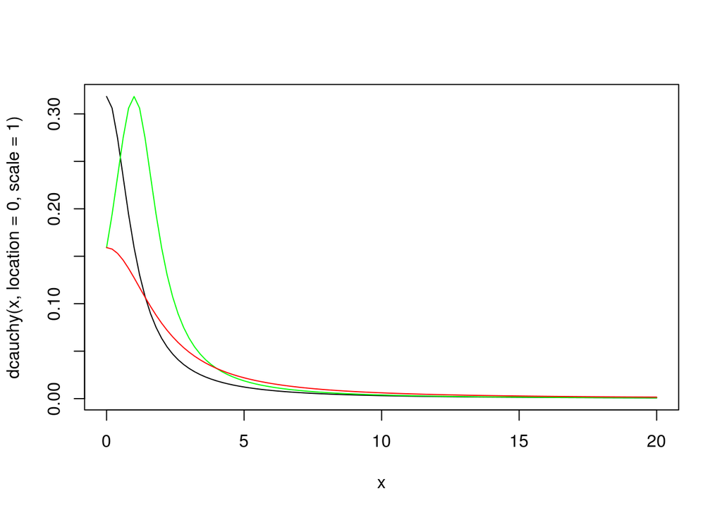

```r
curve(dcauchy(x, location = 0, scale = 1), from=0, to=20)
curve(dcauchy(x, location = 1, scale = 1), from=0, to=20, add=TRUE, col='green')
curve(dcauchy(x, location = 0, scale = 2), from=0, to=20, add=TRUE, col='red')
```

- Exercise 8H5 is a great example to help understand the Metropolis algorithm. Although I have not yet figured out how to model the global flipping example with `map2stan`.

# Chapter 9

## Exponenial Family

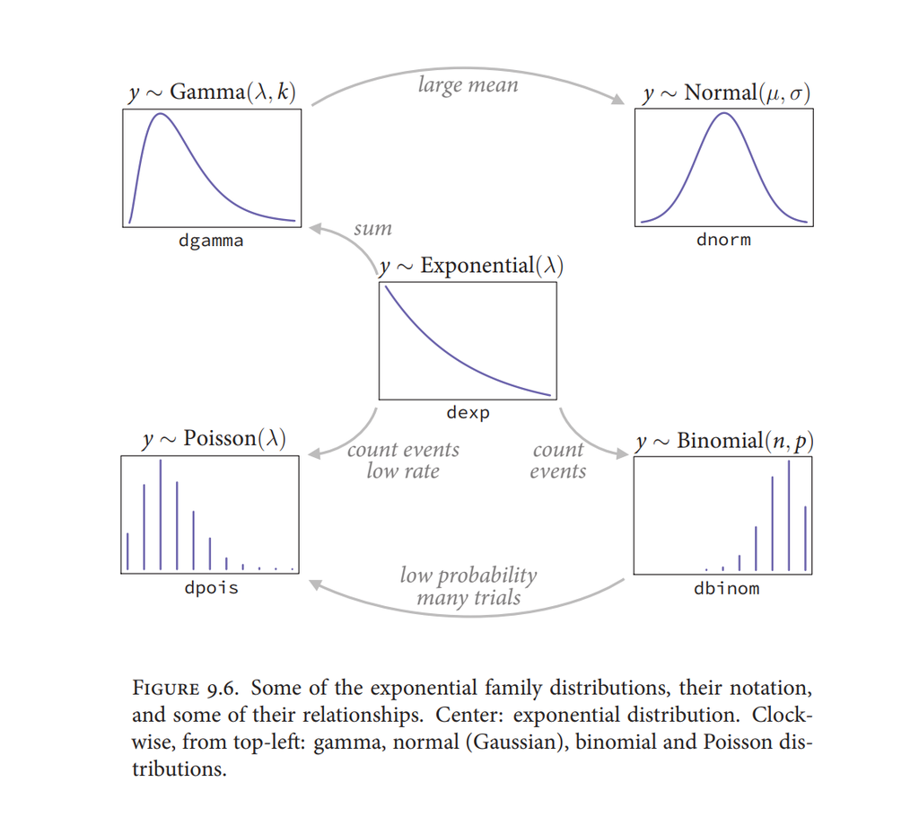

exponential

## Logit / Logistic

**Logit Function**

$$logit(p_i) = \log\frac{p_i}{1-p_i}$$

In a GLM model, where logit is the link function, we model:

$$logit(p_i) = \log \frac{p_i}{1-p_i} = \alpha + \beta x_i$$

After rearranging the above, we have the **Logistic Function**:

$$p = \frac{\exp(\alpha + \beta x_i)}{1 + \exp(\alpha + \beta x_i)}$$

- Note that `map()` uses quadratic approximation, which enforces symmetric uncertainty around the posterior mode, but the logistic regression often leads to asymmetric uncertainty. See solution to 10H1.

## Properties of Maximum Entropy, p267

1. the distribution with the biggest entropy is the widest and least informative distribution.
2. nature tends to produce empirical distributions that have high entropy.
3. it tends to work.
4. It’s the centre of gravity for the highly plausible distribution. p271
- Bayesian updates is just like max entropy in that it produces the least informative distribution that is still **consistent with our assumptions**.

## Definition of Maximum Entropy, p269

The distribution that can happen the most ways is also the maximum entropy distribution, which is the most conservative distribution that obeys its constraints.

## Proof of Gaussian maximum entropy

Uses **KL Divergence** to show that, the **cross entropy** of Gaussian and another potential distribution $H(q, p)$, is equal to the negative entropy of Gaussian $-H(p)$, and the negative of this **cross entropy** is greater than the entropy of this other potential distribution $H(q)$, which implies that the Gaussian entropy is also larger, i.e. $H(p) > H(q)$.

## Max Entropy Constraints

### Normal($\mu$, $\sigma$), p274

`dnorm()`

Density:

$$Pr(x) = \frac{1}{\sqrt{2\pi\sigma^2}} \exp\Bigg(\frac{-(x-\mu)^2}{2\sigma^2}\Bigg)$$

Constraint:

Fixed, finite variance.

#### Generalized Normal Distribution, p273

### Binomal($n$, $p$), p275

`dbinom()`

When only two outcomes can happen and the probably of an outcome is constant across $n$ trials, then the probability of observing the events will be binomally distributed.

Density:

$$Pr(y \mid n, p) = C_n^y p^y (1-p)^{n-y} = \frac{n!}{y!(n-y)!} p^{y}(1-p)^{n-y}$$
where $y$ is the number of event of interest, $n$ is the total number of trials, $p$ is the probability of $y$ at each trial.

Binomal distribution has maximum entropy amongst all distribution that satisfy the following constraints:

1. only two unordered events
2. constant expected value

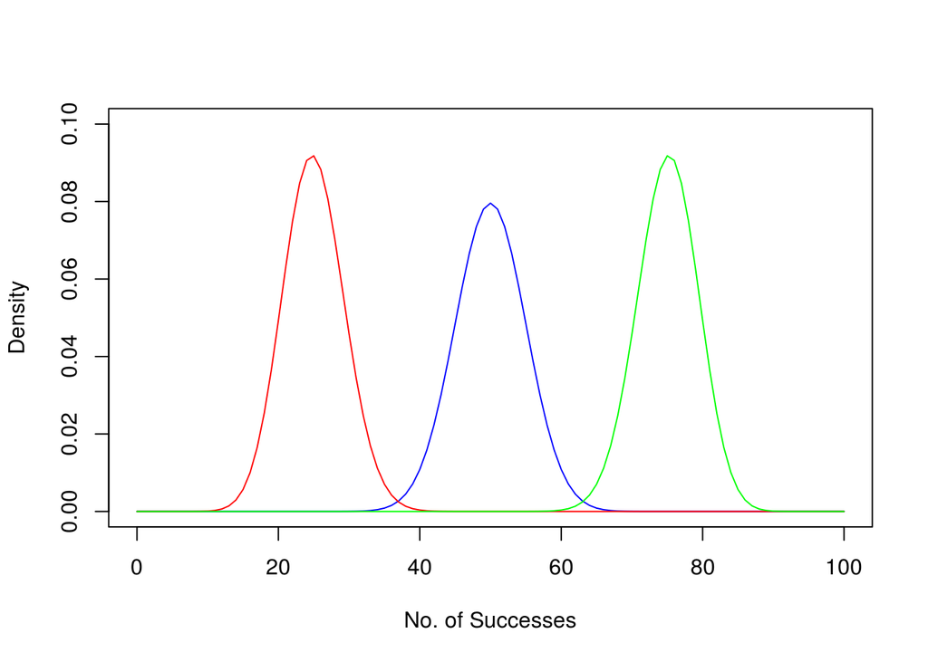

```r
curve(dbinom(x, 100, prob=.5), from=0, to=100,
      xlab = 'No. of Successes', ylab='Density', col='blue', ylim=c(0, .1))
curve(dbinom(x, 100, prob=.25), from=0, to=100, add=TRUE, col='red')
curve(dbinom(x, 100, prob=.75), from=0, to=100, add=TRUE, col='green')
```

### Poisson($\lambda$)

`dpois`

Special case of binomal. When the number of trials $n$ is very large (and usuall unkonwn), and the probability of success, $p$, is very small, then the binomal distribution converges to a Poisson distriubtion with expected rate of event per unit of time $\lambda = np$.

In practice, it is used for counts that never get close to any theoratical maximum.

Same constraints as Binomal.

Density:

$$Pr(\lambda) = \frac{\lambda^k e^{-\lambda}}{k!}$$
where: * $\lambda$ - event rate, i.e. number of events in an interval, or average number of events per interval * $k$ - number of events in an interval, e.g. 0, 1, 2, 3, …

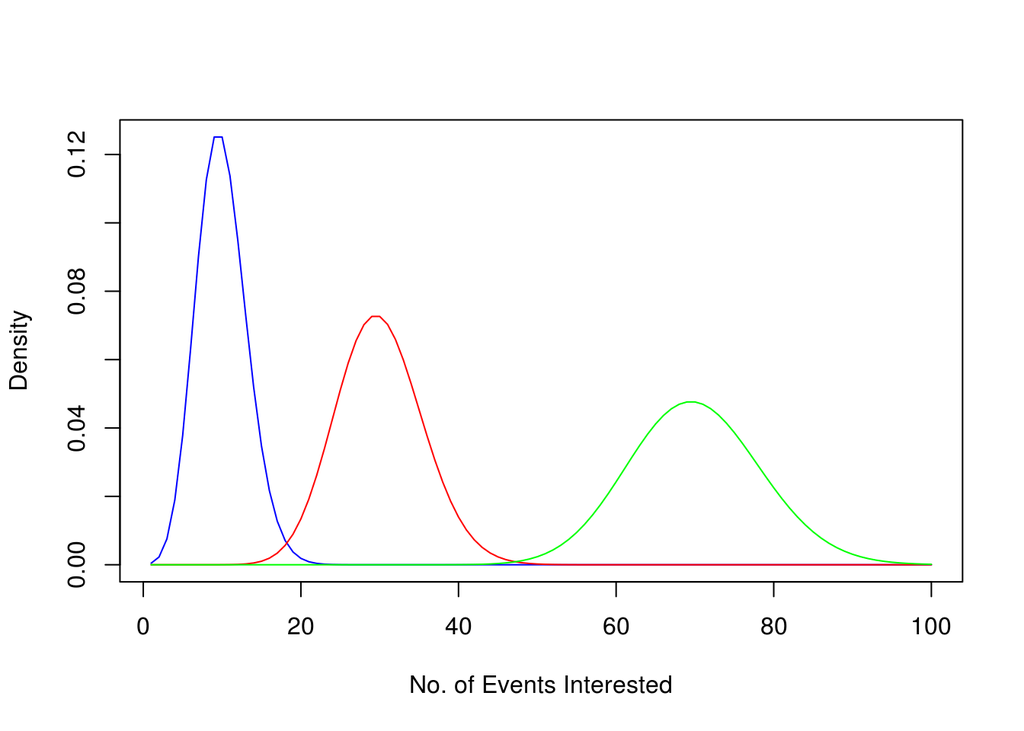

```r
curve(dpois(x, lambda=10), from=1, to=100, n=100,
      xlab = 'No. of Events Interested', ylab='Density', col='blue')
      # ylim=c(0, 3), xlim=c(0, 3))
curve(dpois(x, lambda=30), from=1, to=100, n=100, add=TRUE, col='red')
curve(dpois(x, lambda=70), from=1, to=100, n=100, add=TRUE, col='green')
```

### Exponential($\lambda$), p282

`dexp()`

When the probability of an event is constant in time or across space, then the distribution of events tends towards exponential.

Density:

$$Pr(\lambda, x) = \lambda e^{-\lambda x} \text{, for } x \geq 0$$

Constraints:

1. Constrained to be zero or positive (non-negative continuous)
2. Fixed average displacement, $\lambda^{-1}$, where $\lambda$ is the rate of events.

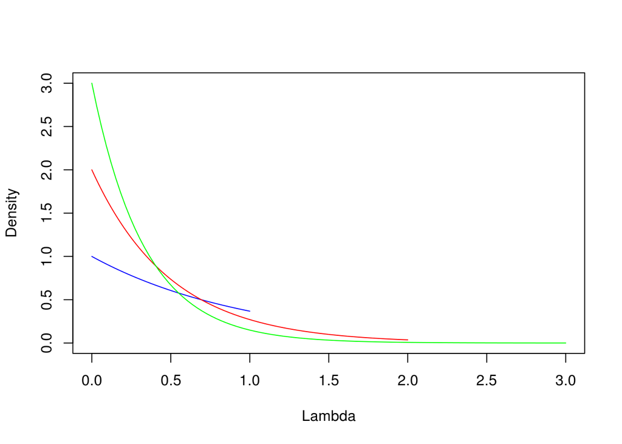

```r
curve(dexp(x, rate=1), from=0, to=1, n=100,
      xlab = 'Lambda', ylab='Density', col='blue',
      ylim=c(0, 3), xlim=c(0, 3))
curve(dexp(x, rate=2), from=0, to=2, n=100, add=TRUE, col='red')
curve(dexp(x, rate=3), from=0, to=3, n=100, add=TRUE, col='green')
```

### Gamma($\lambda$, $k$),

`dgamma`

If an event can only happen after two or more exponentially distributed events happened, the resulting waiting time will be gamma distributed.

More commonly defined with: $\alpha$ - shape, $k$ $\beta$ - rate, $\lambda$

Density: [link](https://en.wikipedia.org/wiki/Gamma_distribution)

$$\begin{aligned}
Pr(x \mid \alpha, \beta) &= \frac{\beta^{\alpha}}{\Gamma(\alpha)}x^{\alpha-1}e^{-\beta x} \text{ , for } x \in (0, +\infty) \\
\Gamma(n) &= (n - 1)! \text{ , for } n \in N^{+}
\end{aligned}$$

Constraints:

1. Constrained to be zero or positive (non-negative continuous)
2. same mean
3. same average logarithm

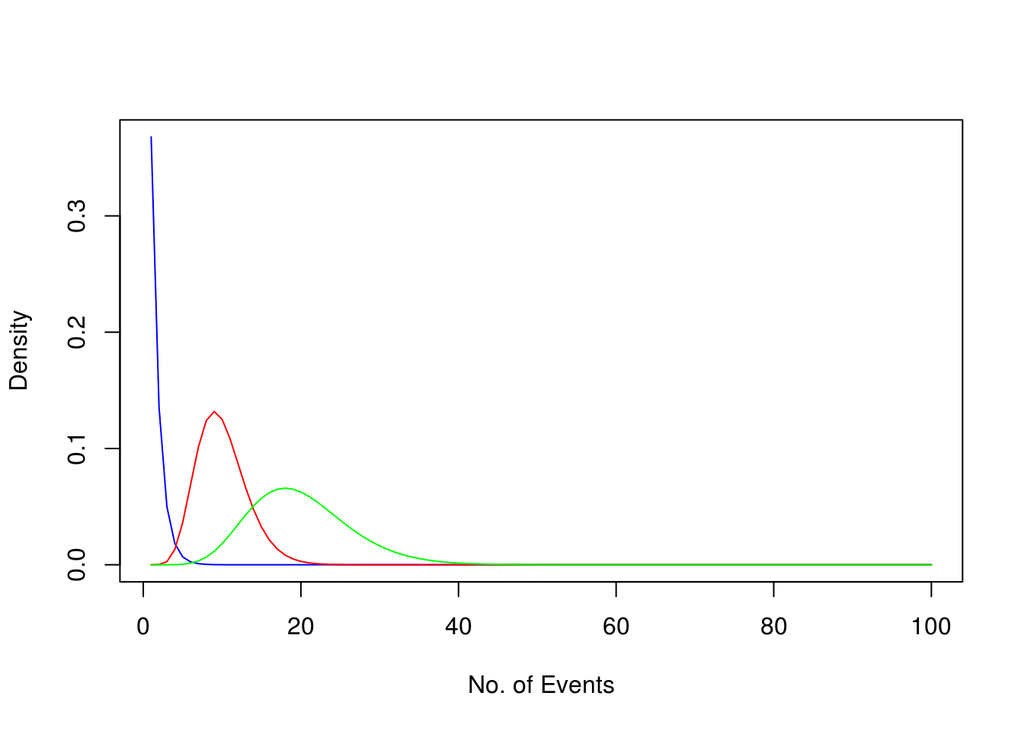

```r
curve(dgamma(x, shape=1, rate=1), from=1, to=100, n=100,
      xlab='No. of Events', ylab='Density', col='blue')
curve(dgamma(x, shape=10, rate=1), from=1, to=100, n=100,
      xlab='No. of Events', ylab='Density', col='red', add=TRUE)
curve(dgamma(x, shape=10, rate=.5), from=1, to=100, n=100,
      xlab='No. of Events', ylab='Density', col='green', add=TRUE)
```

## Geometric($n$, $p$), p328

`dgeom`

Typically used in **survival** or **event history analysis**. Used to predict the number of events until a particular event of interest.

Density function:

$$Pr(y \mid p) = p(1 - p)^{(y-1)}$$
where $y$ is the number of time steps (events) until the terminating event occurred and $p$ is the probablity of that event in each time step.

Constraints:

1. Unbounded counts
2. Constant expected value

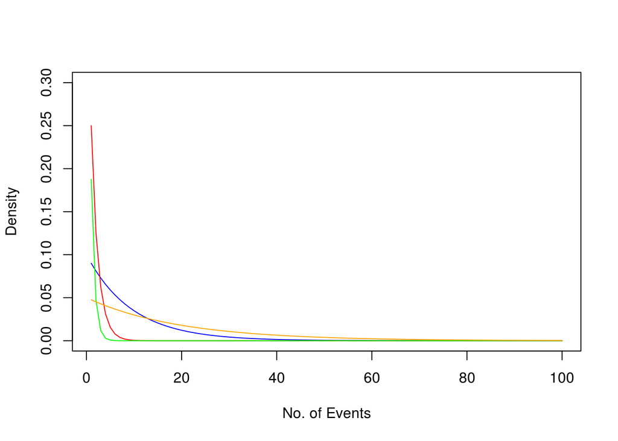

```r
curve(dgeom(x, prob=.1), from=1, to=100, n=100,
      ylim=c(0, .3),
      xlab='No. of Events', ylab='Density', col='blue')
curve(dgeom(x, prob=.5), from=1, to=100, n=100, col='red', add=TRUE)
curve(dgeom(x, prob=.75), from=1, to=100, n=100, col='green', add=TRUE)
curve(dgeom(x, prob=.05), from=1, to=100, n=100, col='orange', add=TRUE)
```

# Chapter 10

## Binomial Regression

Conventional link is **logit**.

In general, the model is of the form of:

$$\begin{aligned}
y &\sim \mathbb{dbinom}(\text{num_of_trials}, \text{prob_of_success}) \\
\mathbb{logit}(\text{prob_of_success}) &= \text{model forumla}
\end{aligned}$$

To model individual behaviour, we can use different intercepts for each group or individual. p299.

### Aggregated Binomial

When data is organized in aggregated format, we can change the value of $\text{num_of_trials}$ to model the problems.

The likelihood of aggregated binomial is different to disaggregated data because in the case of aggregated data we need to deal with the $C_n^y$ multiplier. See density function above.

### Practial Issues

`R`’s `glm` assumes **flat prior**, this can be problematic sometimes. Even very weakly regularizing prirors can resovle these issues. p311.

**Ceiling and floor effect**, p296. When the intercept is large enough to guarantee an outcome, increasing the odds furhter does very little to change the prediction.

Tips from execrises:

- Use `link()` to obtain fitted values for `p` in `dbinom(n, p)`.
- Use `sim()` to obtain simulated results for `y` in the model.

## Possion Regression

**Conventional link for Possion models is the log link.**

Basic form:

$$\begin{aligned}
y &\sim \mathbb{Possion(\lambda_i)} \\
\log(\lambda_i) &= \alpha + \beta x_i
\end{aligned}$$

The parameter $\lambda$ is the **expected value of the outcome** in Possion regression.

In principal the posterior distribution for a GLM may not be multivariate Gaussian, even if all your priors are Gaussian. p319

** Exposure / Offset **: p312, implicitly $\lambda$ in Possion distribution is equal to the expected number of events, $\mu$,** per unit time or distance**, $\tau$, i.e. $\lambda = \mu / \tau$. Hence, in a Possion linear model:

$$\begin{aligned}
y_i &\sim Poisson(\lambda_i) \\
\log \lambda_i &= \log \frac{\mu_i}{\tau_i} = \alpha + \beta x_i \\
\log \lambda_i &= \log\mu_i - \log\tau_i = \alpha + \beta x_i
\end{aligned}$$

Example on p322

```
# construct data.
# daily and weekly data points
exposure <- c(rep(1, 30), rep(7, 4))
mon <- c(rep(0, 30), rep(1, 4))

y <- rpois(30, 1.5)
y_new <- rpois(4, .5*7)
y_all <-c(y, y_new)

d <- data.frame(y=y_all, days=exposure, monastery=mon)
d$log_days <- log(d$days)

m <- map(
  alist(
    y~dpois(lambda),
    log(lambda) ~ log_days + a + b * monastery,
    a ~dnorm(0, 100),
    b~dnorm(0, 1)),
  data=d)

m2 <- map2stan(m)

precis(m)
precis(m2)

post <- extract.samples(m)
lam_old <- exp(post$a)
lam_new <- exp(post$a + post$b)
precis(data.frame(old=lam_old, new=lam_new))
```

## Parameter Posterior Correlation

Higher correlation results in large intervals for the posteriors, **which makes explaining the model based on tables of parameters very difficult**.

The **right way to look at the impact of parameters**, is to use the example shown on p316: extract samples, calculate fitted hypertheticall results with and without a suspicious parameter, then see the probability of differences.

**Centering** the data may help to reduce this problem. It helps HMC also, as high correlation makes the algo less efficient in sampling.

## Multinomial Regression

It is a maximum entropy distribution when:

- more than 2 types of unordered events
- the probability of each event is constant across each trial

**Two approaches**:

1. Explicit approach using a generalization of the logit link.
2. transforms the multinomial likelihood into a series of Possion likelihoods.

### Multinomial Logit, p323

$K$ scores, one for each event type. We compute the probabilities of a particular type of event $k$ as:

$$Pr(k \mid s1, s2, ..., s_K) = \frac{\exp(s_k)}{\sum_{i=1}{K}\exp(s_i)}$$
We need $K-1$ linear models to model $K$ types of events. Each model may or may not share the same predictors. These are all design choices.

Model likelihood with `rethinking::dcategorical()`, such a model built on multinomial distribution may be also called categorical regression model.

## Geometric Regression, p328

Conventional link is also `logit`

`stats::dgeom()` function. PDD:

$$Pr(y \mid p) = p(1-p)^{y-1}$$

Maximum entropy for unbounded counts with constant expected value.

Appropriate domain is for prediction the number of events until a particular event of interest.

# Chapter 11

## Ordered Categorical Outcomes

### Log-cumulative Odds

Calculation:

```
# 11M1

# rating is event frequency
rating <- c(12, 36, 7, 41)
pr_k <- rating / sum(rating)

cum_pr_k <- cumsum(pr_k)

logit(cum_pr_k)
```

When adding predictors, the linear model is subtracted from the log odds (aka. logits/**log-cumulative-odds**), so that an increase in $\beta$ in the linear model corresponds to an **increase** in the average reponse. p338.

`rethinking::dordlogit(phi, cutpoints)` function for ordered logistic differences. `phi` is the model formula, `cutpoints` are parameters.

See example:

```
# show source
dordlogit

dordlogit(1:7, 0, 1:7)

# this gives the same as above
logistic(1:7) - c(0, logistic(1:6))

# the following shows index 3 of the line above
dordlogit(3, 0, 1:7)

logistic(1:7)
pordlogit(1:7, 0, 1:7)
```

Model example

```
data('Trolley')
d <- Trolley
d$female <- 1 - d$male

m10 <- map2stan(
  alist(
    response ~ dordlogit(phi, cutpoints),
    phi <- bc * contact + bi * intention + ba * action +
      bci * contact * intention + bca * contact * action +
      bf * female + bfc * female * contact,
    cutpoints ~ dnorm(0, 10),
    c(bc, bi, ba, bci, bca, bf, bfc) ~ dnorm(0, 10)
  ),
  data = d, chains=4, cores=4,
  start=list(cutpoints=c(-2, -1, -.5, 0, .5, 1, 2))
)
```

## Zero-Inflated Outcomes

Ignoring zero-inflation will tend to **underestimate** the rate of events.

### Zero-Inflated Poisson

`rethinking::dzipois(p, lambda)` - Zero-Inflated Possion prbability distribution, defined as below:

Two parameters:

- probability of zero event, $p$,
- Poisson rate $\lambda$

$$\begin{aligned}
Pr(y \mid p, \lambda) &= p \times 0 + (1-p) \times Pr(y \mid \lambda) \\
Pr(y \mid p, \lambda) &= (1-p) \frac{\lambda^y \exp(-\lambda)}{y!} \\
\end{aligned}$$

See exercise 11H6 for a working model. Key point is how to produce predictions:

- Use `link()` to fit new data, produce `p` and `lambda`.
- mean of `lambda` is `mean((1-p)*lambda)`
- PI or HPDI is `PI((1-p)*lambda)

Example

```
library(rethinking)
# 11H6
data("Fish")
d <- Fish
str(d)
d$log_hours <- log(d$hours)

m12 <- map(
  alist(
    fish_caught ~ dzipois(p, lambda),
    logit(p) <- ap + bpp * persons + bcp * child,
    log(lambda) <- log_hours + al + bp * persons + bc * child + bl * livebait,
    ap ~ dnorm(0, 1),
    c(bpp, bcp) ~ dnorm(0, 5),
    al ~ dnorm(0, 10),
    c(bp, bc, bl) ~ dnorm(0, 10)
  ),
  data=d
)
precis(m12)

# Get prediction
d_pred <- data.frame(
  log_hours=1,
  persons=1,
  child=0,
  livebait=1
)

fish.link <- link(m12, data=d_pred)

p <- fish.link$p
lambda <- fish.link$lambda

# expected_fish_mean
mean((1-p)*lambda)
# expected_fish_PI
PI((1-p)*lambda)
```

### Zero-Inflationed Binomial probability distribution, derived in 11M3.

Define the following:

- $y$ number of successes
- $n$ total no. of trials
- $q$ probablity of success event at each trial
- $p_0$ probability of zero event

$$\begin{aligned}
Pr(0, \mid p_0, q, n) &= p_0 + (1-p_0)q^0(1-q)^{n-0}\\
Pr(y \mid p_0, q, n) &= p_0 \times 0 + (1-p_0) \frac{n!}{y!(n-y)!}q^y (1-q)^{n-y}\\
Pr(y \mid p_0, q, n) &= (1-p_0) \frac{n!}{y!(n-y)!}q^y (1-q)^{n-y}
\end{aligned}$$

## Over-dispersed Outcomes

### Beta-Binomial, p347

Assumes each Binomial observation has its own probability of success.

**Beta distribution** is a probability distribution for probabilities, defined by two parameters:

1. average probability, $\bar{p}$,
2. shape, $\theta$

Max entropy for the same constraints as Binomial.

`dbetabinom(no.trials, prob, theta)` function.

$prob$ and $\theta$ are parameters of beta distribution.

## Under-dispersed Outcomes, p352, 11E4

Typically happens when there is **autocorrelation**.

**State-dependent queuing models** studies these problems. Example is the Conway-Maxwell-Poisson aka COM-Poisson distribution.

### Negative-Binomial / Gamma-Poisson, p350

Assumes each Poisson count observation has its own rate, this rate comes from a gamma distribution.

Max entropy for the same constraint as Poisson.

`dgampois(lambda, scale)` function

Using Gamma-Poisson versus Poisson will result in **more uncertainty** in the posterior distributions, i.e. larger prediction intervals. This uncertainty comes from the additional Gamma distribution, which allows **more plausible** values for the parameters.

**Gamma Distribution** defined by mean $\mu$ and scale $\theta$.

### Do NOT use WAIC

Fall back to DIC.

# Chapter 12

Multilevel models deserves to be the default for regression problems. They can reveal issues not captured by simple models. It’s better to try multilevel first and then realise it is not necessary than to ignore potential issues.

However, they instroduce additinal assumptions in the modelling process. Using maximum entropy priors mitigates this issue somewhat.

Multilevel models are also known as **hierarchical** and **mixed effects** models. p357.

## Pooling / Varying Effects

Assume that the the same parameters across different clusters/groups are draw from a common distribution.

Hyperparameters are learnt from data to determine how much regularization is eventually applied, i.e. it is **adaptive**.

**Shrinkage** effects is stronger when empirical proportion in one bucket is further away from the group mean. p362.

**Complete Pooling** - use average of all clusters - **underfitting**.

**No Pooling** - use individual clusters as standalone - **overfitting**.

**Partial Pooling** - reduce effects of both above.

**Benefits:**

1. Improved estimates for repeat sampling. Single level models either maximally underfit or overfit the data.
2. Improved estimates for imbalance in sampling. Prevents over-sampled clusters from dominating inference.
3. Estimate of variation. Because variation across clusters is modelled explicitly.
4. Avoid averaging, retain variation. Avoid dangerous data transformations.

### Concenration of Measures p360

As models get more complex, concentration of measures phenomenon guarantees that the posterior mode will be far from the posterior median. This is the reason why quadratic approximation doesn’t work for multilevel models, but MCMC does.

### Cauchy Priors in Multilevel Models

Usually work well in multilevel models. However, there are two contexts in which they can be **problematic**.

1. When there isn’t much info in the data with which to estimate the variance. e.g. estimate variance from 5 clusters (ie. 5 observations).
2. In non-linear models with logit and log links, **floor and ceiling** effects sometimes render extreme values of the variance equally plausible as more realistic values. Results is that the sampling of variance parameters swings around over very large values, becuase Cauchy has very thick and long tail. So the chain becomes inefficient, even that it may still work.

**To improve such models, use exponential priors instead.** Exponential is also the maximum entropy prior for standard deviation, provided all we want to say a prior is the expected value.

Gaussian priors shrinks more than Cauchy priors for extreme samples, see exercise 12M3.

## Multilevel Model Predictions

Need to distinguish between 2 types of predictions (book classifies them into 3 types but essentially 2, p382):

1. **Retrodiction** and prediction for a **known** cluster
2. Prediction for an **unknown** cluster

### Retrodict / Known Clusters

Retrodictions should not be expected to match samples, because of the shrinkage introduces. Should expect even a perfectly good model fit will differ from the raw data in a **systematic** way that reflects shrinkage.

Prediction for a known cluster should use the parameters specifically for that cluster, such as its particular intercept (in addition to the group mean intercept).

For both cases we can use `link()` and `sim()` directly. p377 also has examples showing useage without these functions.

### Prediction for Unknown Clusters

There is the effect and variance from the group, represented by the group averages, as well as variation for a specific group, which is modelled / sampled from the distribution from pooling, defined by the hyperparameters.

In this case we can use `link()` and `sim()` with `replace` argument. p379

Code 12.35 is key here as it shows how to generate a sample from the pooling distribution. In essense it does the following:

1. extract samples from posterior
2. generate random samples defined by hyperparameters in the extracted samples above.
3. pass random samples from step 2 to `link()` with `replace=`. Name for these random samples must match the one used in the model.

Usually this results in wider intervals than a single-level model, as it models the variation across different clusters.

# Chapter 13

`rethinking::dmrnorm()` or `dmvnorm2()`, or `dmvnormNC()` for multinomial distributions.

`rethinking::LKJcorr(eta=2)` - weakly informative prior on $\rho$ that is skeptical ofextreme correlations near -1 or 1.

`rethinking::GPL2()` - Squared distance Gaussian process prior, p413

## Varying Slope

### Covariance Matrices

$$S = diag(\sigma_i) \times R \times diag(\sigma_i)$$
where $R$ is the correlation matrix.

Example Model, p393-394:

$$\begin{aligned}
W_i \sim& \text{Normal}(\mu_i, \sigma)\\
\mu_i =& \alpha_{CAFE[i]} + \beta_{CAFE[i]}A_i\\
\Bigg[ \begin{array}{cc} \alpha_{CAFE[i]} \\ \beta_{CAFE[i]} \end{array} \Bigg]
\sim& \text{MVNormal}\Bigg(\Bigg[ \begin{array}{cc} \alpha \\ \beta \end{array}
\Bigg], S\Bigg) \\
S =& \Bigg(
\begin{array}{cc}
\sigma_{\alpha} & 0\\
0 & \sigma_{\beta}
\end{array}
\Bigg) R \Bigg(
\begin{array}{cc}
\sigma_{\alpha} & 0\\
0 & \sigma_{\beta}
\end{array}
\Bigg)
\end{aligned}$$

```
## R code 13.12
m13.1 <- map2stan(
    alist(
        wait ~ dnorm( mu , sigma ),
        mu <- a_cafe[cafe] + b_cafe[cafe]*afternoon,
        c(a_cafe,b_cafe)[cafe] ~ dmvnorm2(c(a,b),sigma_cafe,Rho),
        a ~ dnorm(0,10),
        b ~ dnorm(0,10),
        sigma_cafe ~ dcauchy(0,2),
        sigma ~ dcauchy(0,2),
        Rho ~ dlkjcorr(2)
    ) ,
    data=d ,
    iter=5000 , warmup=2000 , chains=2 )
```

### Non-Centered Parameterization, (NC)

**Standardized adaptive prior** for varying effects models. Sometimes, NC are better (avoids divergent iterations warning from `Stan`) but not always the case. See practice 13M3.

**NC tends to be better when the variation across clusters is very small - close to zero, or poorly identified by the data.**

For example standardizing both mean and variance of normal distribtions to be $\mathcal{N}(0, 1)$.

In this form we no longer need the covariance matrix, but **only the correlation matrix**, since the scaler has been moved to the linear model.

It’s possible to further extend this by using **Cholesky Decomposition** of the correlation matrix, $R=LL^T$. With this we can even take the correlation out of the prior.

Strategy is to sample a vector of uncorrelated z-scores and then multiply by $L$ and the standard deviations to get the varying effects with correct scale and correlation. `dmvnormNC()` does this for us. Note with `dmvnormNC()`, only `sigma` and `Rho` (standard deviation and correlation) need to be provided. The mean should always be **in the model, not the prior**, for non-centered parameterization.

Benefits of non-centered parameterization:

1. handles divergent iterations,
2. samples more efficiently.

Cost of non-centered forms:

1. looks more confusing.
2. varying effects parameters emerge as z-scores, needs to be processed further to be interpreted.
3. Not all combinations of model structure and data beneifit from the non-centered parameterization.

Example Model:

$$\begin{aligned}
L_i &\sim \text{Binomial}(1, p_i) \\
logit(p_i) &= \mathcal{A}_i + (\mathcal{B}_{P, i} + \mathcal{B}_{PC}C_i)P_i \\
\mathcal{A}_i &= \alpha + \alpha_{ACTOR[i]} + \alpha_{BLOCK[i]} \\
\mathcal{B}_{P,i} &= \beta_P + \beta_{P,ACTOR[i]} + \beta_{P, BLOCK[i]} \\
\mathcal{B}_{PC,i} &= \beta_{PC} + \beta_{PC,ACTOR[i]} + \beta_{PC, BLOCK[i]} \\
\end{aligned}$$

Why are there separate intercepts in the model above? Because if you expand the second formula, you’ll see that these intercepts form the parameters with $P_i$ and $C_i P_i$.

Example code:

```
m13.6NC <- map2stan(
  alist(
    pulled_left ~ dbinom(1,p),
    logit(p) <- A + (BP + BPC*condition)*prosoc_left,
    A <- a + a_actor[actor] + a_block[block_id],
    BP <- bp + bp_actor[actor] + bp_block[block_id],
    BPC <- bpc + bpc_actor[actor] + bpc_block[block_id],
    # adaptive NON-CENTERED priors
    c(a_actor,bp_actor,bpc_actor)[actor] ~
                            dmvnormNC(sigma_actor,Rho_actor),
    c(a_block,bp_block,bpc_block)[block_id] ~
                            dmvnormNC(sigma_block,Rho_block),
    c(a,bp,bpc) ~ dnorm(0,1),
    sigma_actor ~ dcauchy(0,2),
    sigma_block ~ dcauchy(0,2),
    Rho_actor ~ dlkjcorr(4),
    Rho_block ~ dlkjcorr(4)
  ),
  data=d , iter=5000 , warmup=1000 , chains=3 , cores=3 )
```

## Gaussian Process Regression, p410

For modeling **continuous categories**.

Multivariate prior:

$$\begin{aligned}
\gamma &\sim \text{MVNormal}([0, \dots, 0], K) \\
K_{ij} &= \eta^2\exp(-\rho^2 D_{ij}^2) + \delta_{ij}\sigma^2
\end{aligned}$$

Where $D_{ij}$ is input data, $\eta$, $\delta$ and $\sigma$ are parameters, the model computes posterior distributions for these three parameters.

$\eta^2$ is the maximum covariance between any two points (soceities in book example)

$\delta_{ij}\sigma^2$ provides for extra covariance beyond $\eta^2$ when $i = j$.

Distribution for Gaussian Process with square distance: `GPL2()`

From $K$ we can get the **correlation** matrix by using `cov2cor()`.

**Automatic relevance determination** (p419) is the term used in machine learning corre- sponding to the term “hierarchical modeling” in statistics. In either case, the idea is that hyperparameters are estimated from data (in Bayesian inference, via the joint posterior distribution) rather than being preset.

Best to model GP in `Stan` directly, or `GPstuff`. `Stan` manual on GP is well written.

New tools such as `GPflow` implements GP with `tensorflow`, which will utilize the latest and new hardware.

Use `WAIC` for model comparsing, particularly look at `pWAIC` (the effective number of parameters). Many times models with adaptive regularization end up with fewer effective parameters. See practice 13M4.

Possion GLM models tend to have more free parameters then you might expect, use `WAIC` and check `pWAIC`.

# Chapter 14

## Measurement Error

Error can be modelled both on **outcome** and **predictor** variables.

In both cases, the observed values can be model with a distribution, e.g. Normal, with the estimated mean of the distrubtion be the **new** overall model outcome, and the standard error of the observed outcome becomes the standard deviation of this distribution.

In other words, for outcome error modeling, let observed outcomes be $D_{\text{observed}}$, its **standard error** be $\sigma$, both are part of input data, then we insert into the model:

$$D_{\text{observed}} \sim \mathcal{N}(D_{\text{estimated_param}}, \sigma)$$
Result is that the samples with high standard errors are regularized more. In other words, samples with lower standard errors have higher influence of the slope (parameter), whereas samples with higher standard errors are influenced (regularized) more by the slope.

Same applies to predictor error. The estimated predictor becomes part of the main model. p430 example.

```
dlist <- list(
  div_obs=d$Divorce,
  div_sd=d$Divorce.SE,
  mar_obs=d$Marriage,
  mar_sd=d$Marriage.SE,
  A=d$MedianAgeMarriage )

m14.2 <- map2stan(
  alist(
      div_est ~ dnorm(mu,sigma),
      mu <- a + bA*A + bR*mar_est[i],
      div_obs ~ dnorm(div_est,div_sd),
      mar_obs ~ dnorm(mar_est,mar_sd),
      a ~ dnorm(0,10),
      bA ~ dnorm(0,10),
      bR ~ dnorm(0,10),
      sigma ~ dcauchy(0,2.5)
  ),
  data=dlist ,
  start=list(div_est=dlist$div_obs,mar_est=dlist$mar_obs) ,
  WAIC=FALSE , iter=5000 , warmup=1000 , chains=3 , cores=3 ,
  control=list(adapt_delta=0.95)
)
```

### How to do this with `map2stan()`, p428:

- **WAIC should be turned off in `map2stan()` with `WAIC=FALSE` parameter.** WAIC will note compute correctly here.
- **Start values must be given,**, so that `map2stan()` konws how many parameters it needs, can set start values for $D_{\text{estimated}}$ with the observed values $D_{\text{observed}}$.
- `control=list(adapt_delta=0.95)` - sets a higher **target acceptance rate**.

## Imputation / Missing Data

Imputing data, two methods:

1. modeling missing data as random, **MCAR**, Missing Completely At Random
2. Not at random.

### MCAR

Let assume $N_i$ is the predictor with missing value.

$$\begin{aligned}
\mu_i =& \alpha + \beta_N N_i + \beta_M \log(M_i) \\
N_i \sim& \mathcal{N}(\nu, \sigma_N)
\end{aligned}$$
Note that the distrubutional assumption about the predictor that contains missing values does not contain any information for each case. It **implicitly** assumes that missing values are **randomly** located among the cases. See exercise 14M1.

Example code:

```
m <- map2stan(
  alist(
    kcal ~ dnorm(mu, sigma),
    mu <- a + bN*neocortex + bM*logmass,
    neocortex ~ dnorm(nu, sigma_N),  # missing value drawn based on this line
    a ~ dnorm(0, 100),
    c(bN, bM) ~ dnorm(0, 10),
    nu ~ dnorm(0.5, 1),
    sigma_N ~ dcauchy(0, 1),
    sigma ~ dcauchy(0, 1)
  ),
  data=data_list, iter=4e4, chains=2
)
```

### Model relationship amongst predictors

Additional model between predictors. In this case, if there is some relationship between the predictors, i.e. a slope, the imputed values will reflect that trend.

Note that we are making assumptions here. **Key is to try different assumptions and see how sensitive your inference is to them.**

$$\begin{aligned}
N_i \sim& \mathcal{N}(\nu, \sigma_N) \\
\nu =& \alpha_N + \gamma_M \log(M_i)
\end{aligned}$$

When using imputation, there is usually more data, which results in **smaller** standard errors comparing models with WAIC.

Example code:

```
m <- map2stan(
  alist(
    kcal ~ dnorm(mu, sigma),
    mu <- a + bN*neocortex + bM*logmass,
    neocortex ~ dnorm(nu, sigma_N),
    nu <- a_N + gM * logmass,        # this is the linear model
    a ~ dnorm(0, 100),
    c(bN, bM, gM) ~ dnorm(0, 10),
    a_N ~ dnorm(0.5, 1),
    sigma_N ~ dcauchy(0, 1),
    sigma ~ dcauchy(0, 1)
  ),
  data=data_list, iter=4e4, chains=2
)
```